# Twitter Analytics - DataONE

## DataONE Twitter Metrics

This report contains information about DataONE’s Twitter account, @DataONEorg, and how effective it is at engaging a wider audience of data repository professionals, researchers, students, and other data organizations.

### How has DataONE’s Twitter account increased its reach over time?

The DataONE account currently has 3788 followers.

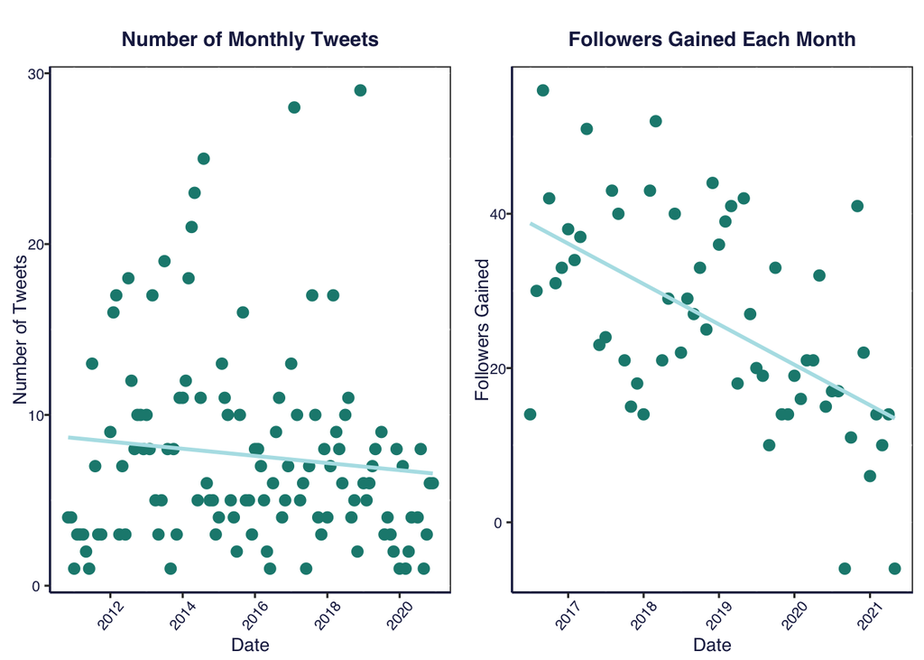

These next two graphs dig into the metrics associated with each Tweet. Every organic Tweet has a certain number of engagements (that is, the number of times users interact with the Tweet) and impressions (the number of times users are served that Tweet in their timeline). The data presented are normalized on a per Tweet basis because of course there will be more total engagements and impressions as the quantity of Tweets increases.

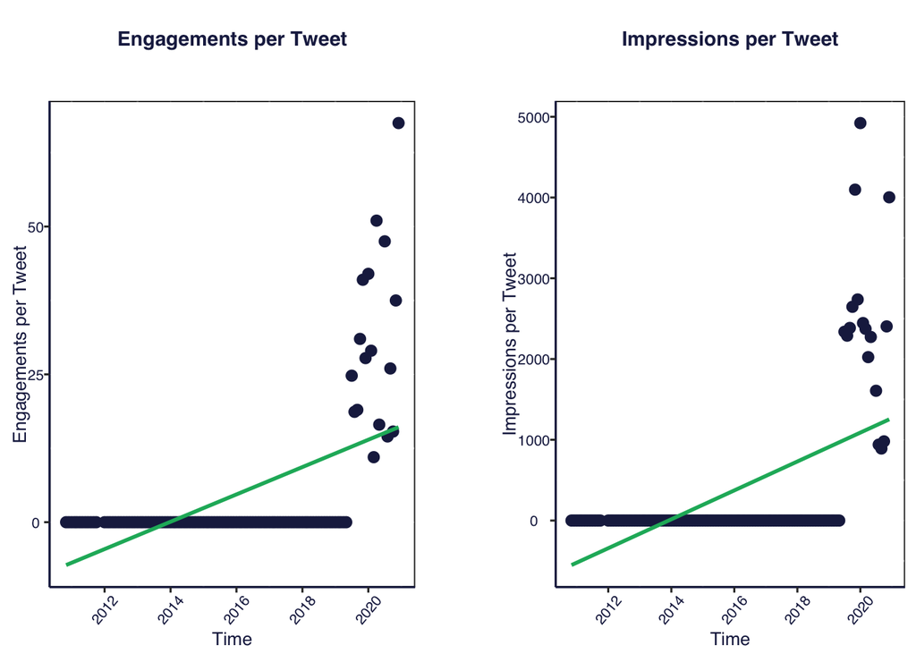

| Tweet | Timestamp | Engagements |
| --- | --- | --- |
| #Researchers - how do you choose a #repository for your #data? Do you ask colleagues what repo they use? Do you look at your funding requirements? Do you just google it? Tell us in the replies! #datah… | 2020-12-11 16:55:01 | 180 |
| How do you, as a working scientist, become an open science culture change agent? Where do you start? What do you need to know? The Open Science Handbook has just been published and looks like a great … | 2020-12-14 22:03:47 | 125 |
| Metajam R package now on CRAN: Use data from DataONE while leveraging metadata info in R. Builds on DataONE API & R package, currently supports EML & tested on @arcticdatactr @EDIgotdata & @nceas KNB.… | 2020-11-03 19:00:05 | 107 |
| It is with great sadness that we learned of the passing of Bob Sandusky on Friday April 10 after his decade-long fight with cancer. We have lost a great friend and colleague who has been a part of the… | 2020-04-14 18:27:25 | 89 |
| Congratulations to @datadryad and @ZENODO_ORG on their recent award and commitment to forwarding open infrastructure solutions for researchers and publishers https://t.co/YAicP8wNFm | 2019-07-17 17:56:23 | 78 |

| Tweet | Timestamp | Impressions |
| --- | --- | --- |
| How do you, as a working scientist, become an open science culture change agent? Where do you start? What do you need to know? The Open Science Handbook has just been published and looks like a great … | 2020-12-14 22:03:47 | 9908 |
| #Researchers - how do you choose a #repository for your #data? Do you ask colleagues what repo they use? Do you look at your funding requirements? Do you just google it? Tell us in the replies! #datah… | 2020-12-11 16:55:01 | 9303 |
| Metajam R package now on CRAN: Use data from DataONE while leveraging metadata info in R. Builds on DataONE API & R package, currently supports EML & tested on @arcticdatactr @EDIgotdata & @nceas KNB.… | 2020-11-03 19:00:05 | 7856 |
| Congratulations to @datadryad and @ZENODO_ORG on their recent award and commitment to forwarding open infrastructure solutions for researchers and publishers https://t.co/YAicP8wNFm | 2019-07-17 17:56:23 | 5791 |
| Data and biodiversity literacy; a need for early investment in our workforce. Check out the new perspective paper by the BLUE initiative, including @DataONEorg and @nceas education lead @aebudden. htt… | 2019-12-19 17:39:32 | 5521 |

The number of engagements includes all actions that a user could take with a Tweet, including Retweeting, clicking anywhere on the Tweet, or favoriting the Tweet. To dig further into those engagements, the following graphs show the number of likes and retweets on a per Tweet basis.

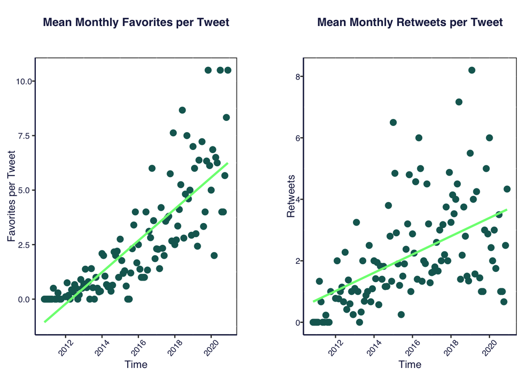

| Tweet | Timestamp | Likes |
| --- | --- | --- |
| We’ve got something new that we think you’ll like… check out our community-owned Data Management Skillbuilding Hub – a one-stop-shop for teaching & learning best practices for data mgmt. Use, share & … | 2018-06-04 16:03:11 | 39 |
| So very appreciative of the recognition by @ESIPfed as ESIP Partner of the Year. We are excited for the changes coming in 2019 and our continued growth and collaboration into 2020 and beyond. Thank yo… | 2019-01-17 17:11:11 | 26 |
| Metajam R package now on CRAN: Use data from DataONE while leveraging metadata info in R. Builds on DataONE API & R package, currently supports EML & tested on @arcticdatactr @EDIgotdata & @nceas KNB.… | 2020-11-03 19:00:05 | 24 |
| Congratulations to @datadryad and @ZENODO_ORG on their recent award and commitment to forwarding open infrastructure solutions for researchers and publishers https://t.co/YAicP8wNFm | 2019-07-17 17:56:23 | 24 |
| #Researchers - how do you choose a #repository for your #data? Do you ask colleagues what repo they use? Do you look at your funding requirements? Do you just google it? Tell us in the replies! #datah… | 2020-12-11 16:55:01 | 23 |

| Tweet | Timestamp | Retweets |
| --- | --- | --- |
| We’ve got something new that we think you’ll like… check out our community-owned Data Management Skillbuilding Hub – a one-stop-shop for teaching & learning best practices for data mgmt. Use, share & … | 2018-06-04 16:03:11 | 37 |
| Looking for a rewarding summer #internship in #opendata? Join the @DataONEorg team for a nine week paid internship and work remotely. Full information at https://t.co/6vSpOpP7Tx https://t.co/pKlMYk5X7… | 2019-02-27 00:29:33 | 24 |
| Like using R for statistics? Want to use R with @DataONEorg? Now you can! DataONE R Client released today. http://t.co/I0WoWb0KJ5 | 2013-02-25 20:28:44 | 21 |
| Nice resource: syllabus & materials to teach software tools to biologists @ethanwhite @datacarpentry http://t.co/ZRDnmqrkLF #nceasdatafuture | 2015-09-10 18:15:08 | 20 |
| And we’re up: DataONE Goes Live: http://t.co/IlRMSv2y. Join us in a search for data. | 2012-07-23 14:57:09 | 19 |

#### Distribution of replies, retweets, and organic tweets

Analyzing the ratio of replies, retweets and organic tweets can tell you a great deal about the type of account you’re analysing. No one likes a Twitter account that exclusively retweets for instance, without any individual content. Finding a good ratio of replies, retweets and organic tweets is therefore a key metric to monitor if one wishes to improve the performance of an account.

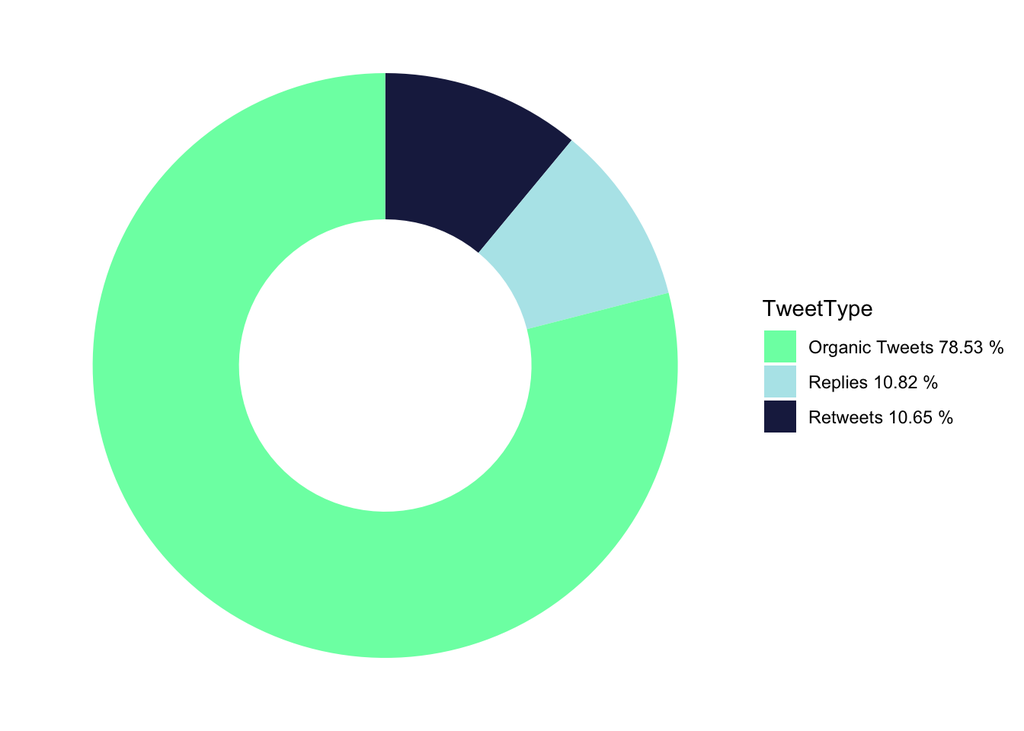

### Engagement with the larger Arctic Research / Policy Community

One way to understand how impactful our Tweets are is by looking at the influential Twitter accounts that are mentioning @ArcticDataCtr (3788 followers) in their Tweets. Influential accounts in the Arctic research space: PolarImpact (3235 followers), Polar_Research (3235 followers), PridePolar (10090 followers), PopePolar (4128 followers), IARPCCollab (5721 followers), Toolik (5721 followers), IARC_Alaska (5721 followers), ArcticResearch (5721 followers), and US_APECS (946 followers).

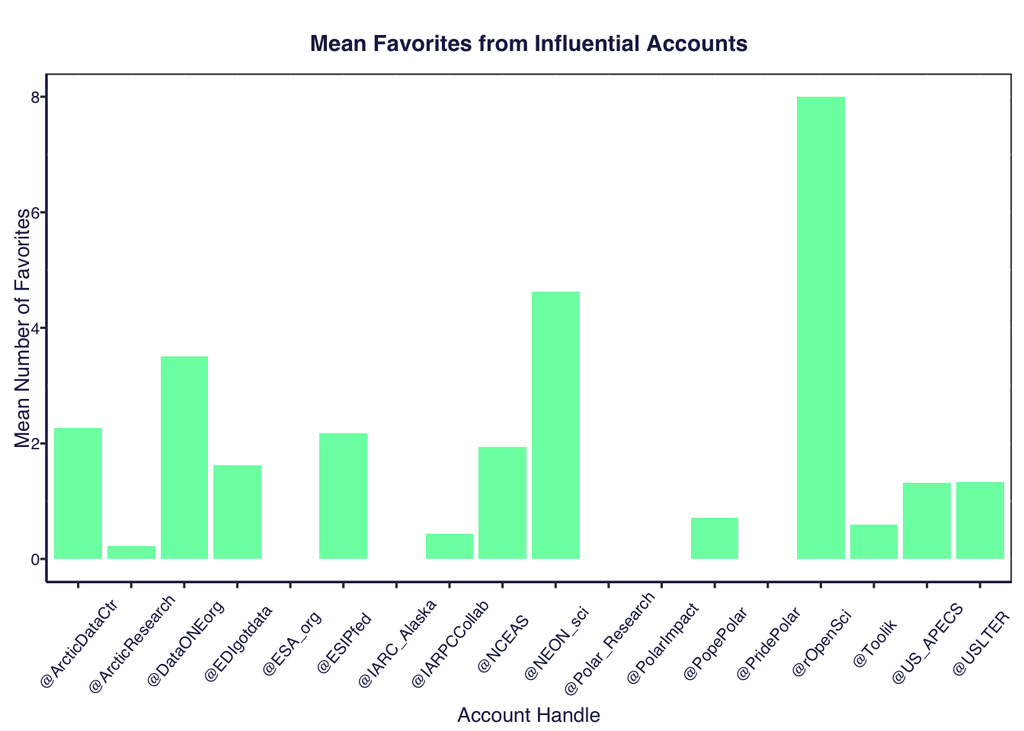

This graph illustrates that the Arctic Data Center’s organic tweets are favorited often when we are mentioned and/or retweeted by some accounts (eg **@rOpenSci** with a mean of 8 favorites per tweet, **@NEON_sci** with a mean of 4.62 favorites per tweet, and **@DataONEorg** with a mean of 3.5 favorites per tweet - compared to a mean of 2.27 favorites on the @ArcticDataCtr account). On the flip side, there are some accounts that when we’re mentioned, the tweets get no favorites at all (eg **@Polar_Research** with a mean of 0 favorites per tweet, **@ESA_org** with a mean of 0 favorites per tweet, and **@IARC_Alaska** with a mean of 0 favorites per tweet).

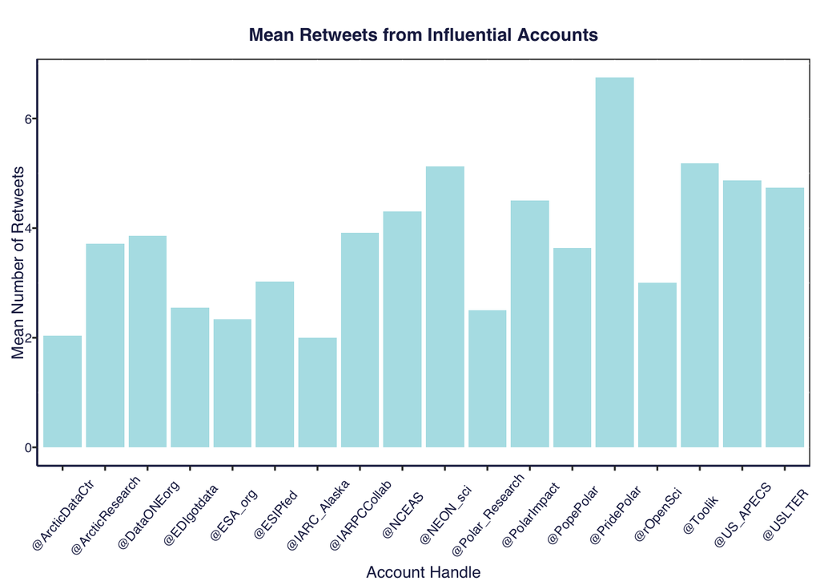

These graphs illustrate places where we should increase our reach - focus on generating content for these influential accounts to favorite and retweet.

### When is the best day and time to post tweets?

Obviously we want to make sure we’re tweeting at the right times, so that our community will see and interact with those tweets. Only organic tweets are included in this analysis because engagements and impressions are not calculated the same way for retweets or replies.

#### Does it matter what time the tweets are sent out to the community?

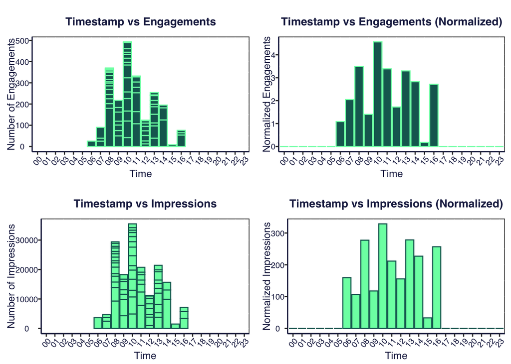

#### What about the day of the week?

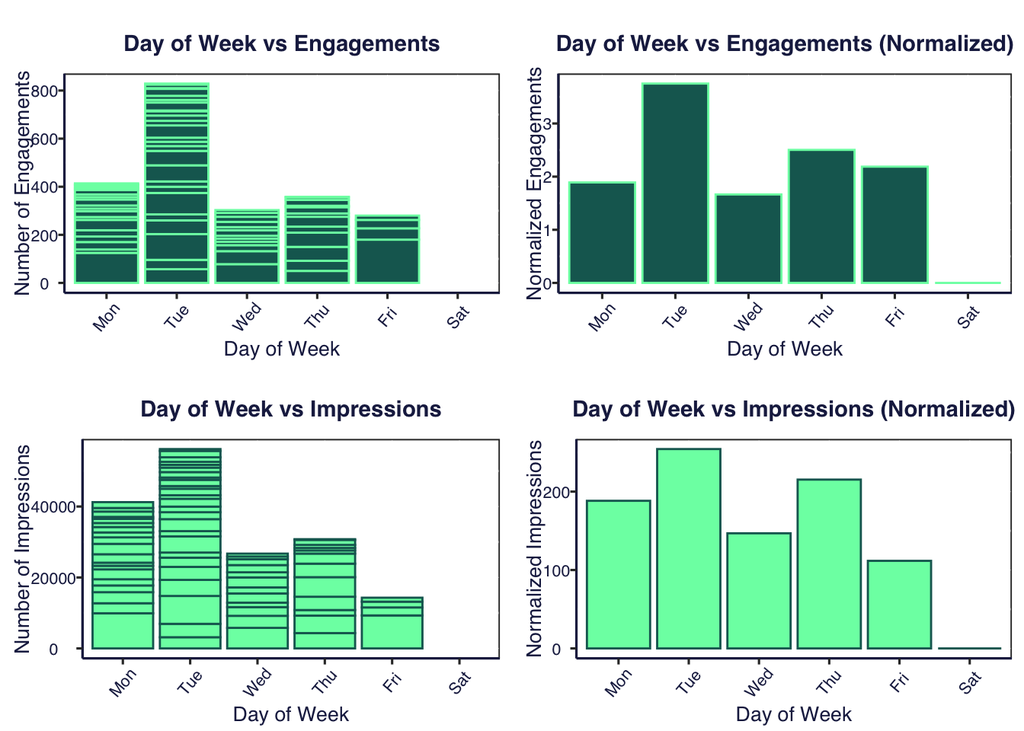

### Should we include photos with Tweets or not?

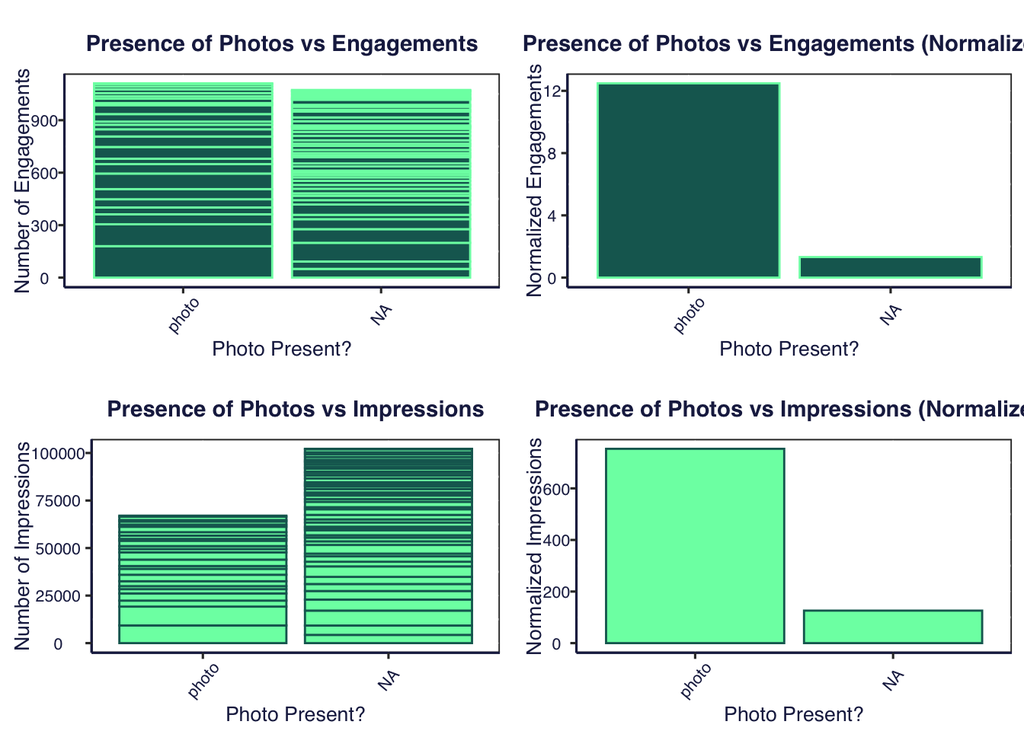

### Data Collection - Summary

Data was collected manually on the first of the month from https://analytics.twitter.com/user/dataONEorg/home. In addition to parameters not necessary to this analysis, this summary file contains:

- month: month of Tweet information
- year: year of Tweet information
- tweets: number of Tweets that month
- profile-visits: number of times users visited the @dataONEorg profile page
- new-followers: number of new followers gained (gross new followers; does not account for followers lost)
- tweet-impressions: number of times users are served @dataONEorg tweets in timeline, search results, or from the profile
- mentions: number of times @dataONEorg was mentioned in tweets
- number-followers: number of followers, manually copied from https://twitter.com/dataONEorg.
  - Number of followers is the only piece of data in this file that is only available from Twitter at the time you access the site i.e. it is not made available with the rest of the data in this dataset. Thus, there are NAs for dates prior to the time I started to collect this data or for dates before I realized this data was ephemeral.

### Data Collection - Monthly Tweets

Data was scraped using the R package rtweet. In addition to parameters not necessary to this analysis, this data contains the following parameters:

- status_id: the identifier for the Tweet, which can be used to find the permanent URL
- created_at: the time the Tweet was sent (GMT)
- text: the text (content) of the Tweet
- display_text_width: how many characters are in the Tweet
- reply_to_status_id: whether the Tweet was a reply
- reply_to_screen_name: who the Tweet was a reply to
- is_retweet: whether the Tweet was a retweet
- favorite_count: number of likes
- retweet_count: number of retweets
- hashtags: what hashtags were used in the Tweet content
- media_type: what type of media was attached to the Tweet
- mentions_screen_name: what other Twitter accounts were mentioned (@) in the Tweet

Additionally, Tweet-level data was also downloaded from https://analytics.twitter.com/user/dataONEorg/home, and in addition to parameters not necessary to this analysis, this data contains the following additional parameters:

- Tweet.id: the identifier for the Tweet, which can be used to find the permanent URL
- impressions: number of times users are served the tweet in timeline, search results, or from the @ArcticDataCtr profile
- engagements: total number of times a user interacted with a Tweet. Clicks anywhere on the Tweet, including Retweets, replies, follows, likes, links, cards, hashtags, embedded media, username, profile photo, or Tweet expansion
- engagement.rate: number of engagements divided by impressions
- replies: number of replies that Tweet generated
- user.profile.clicks: number of times a user clicked on the @ArcticDataCtr profile from that particular tweet
- URL.clicks: number of times that URL within the tweet was clicked
- hashtag.clicks: number of times any of your hashtags were clicked from that tweet
- detail.expands: number of times users clicked ‘see more’ on your tweet
- permalink.clicks: clicks on the Tweet permalink
- follows: times a user followed you directly from the Tweet
- media.views: number of times media attached to the Tweet is viewed
- media.engagements: an interaction on a tweet that has a piece of media (photo, vine, other video, etc) in it

Data scraped from rtweet and downloaded from the Twitter metrics page were joined based on the Tweet id / status_id variable.